# Notebook

En este pequeño post vamos a *analizar* (en realidad no, sólo a trazar grafiquitas con algunos datos de interés) datos del Consejo Nacional de Ciencia y Tecnología (CONACYT), que hasta hace unos días me listaba entre sus becarios nacionales. Pero bueno, ¿qué es el CONACYT?, según wikipedia:

> El Consejo Nacional de Ciencia y Tecnología (Conacyt) es un organismo público descentralizado del gobierno federal mexicano dedicado a promover y estimular el desarrollo de la ciencia y la tecnología en ese país. Tiene la responsabilidad oficial para elaborar las políticas de ciencia y tecnología nacionales.

> Por medio del Conacyt es posible para los estudiantes conseguir apoyo económico a fin de realizar estudios de posgrado (maestría o doctorado) en universidades con reconocida excelencia académica dentro y fuera del país.

En resumen el CONACYT posibilita que muchos de nosotros (jóvenes mexicanos) ingresemos a un programa de posgrado, mismo que debe pertenecer a un *padrón de posgrados de calidad*.

```python
import pandas as pd
import matplotlib.pyplot as plt
import matplotlib as mpl
plt.style.use("ggplot")
mpl.rcParams['xtick.labelsize'] = 6
mpl.rcParams['ytick.labelsize'] = 6
%matplotlib inline

# Datos tomados de: http://datosabiertos.conacyt.gob.mx/publico/default.aspx
filename = "data/becas_nacionales.csv"
data = pd.read_csv(filename)
```

## Por género

```python
genero = data['Genero'].value_counts()
print("Mujeres: {0}".format(genero.get_value("F")))
print("Hombres: {0}".format(genero.get_value("M")))
```

```
Mujeres: 10954
Hombres: 12646
```

## Por estados

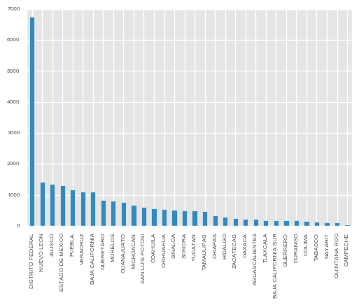

```python
estados = data['Entidad Federativa'].value_counts()
x = range(len(estados))
plt.bar(x, estados.get_values(), 0.5, align="center")
plt.xticks(x, estados.keys(), rotation="vertical")
plt.xlim(min(x)-0.5, max(x)+0.5);
```

## Áreas de conocimientos

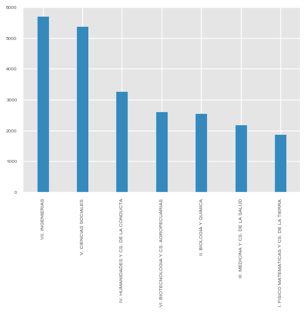

```python
acon = data['Area de Conocimiento'].value_counts()
x = range(len(acon))
plt.bar(x, acon.get_values(), 0.3, align="center")
plt.xticks(x, acon.keys(), rotation=90)
plt.xlim(min(x)-0.5, max(x)+0.5);
```

## Por instituciones

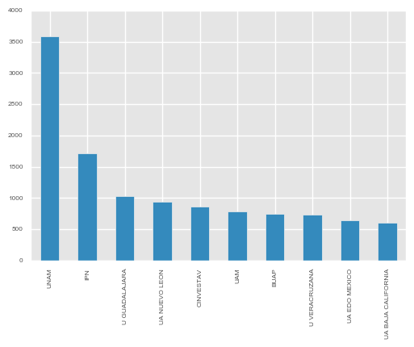

```python
inst = data['Institucion'].value_counts()
n = 10
x = range(len(inst))[:n]
plt.bar(x, inst.get_values()[:n], 0.5, align="center")
plt.xticks(x, inst.keys()[:n], rotation=90)
plt.xlim(min(x)-0.5, max(x)+0.5);
```

```python
data['Nivel'].value_counts()
```

```
2. MAE    17034
1. DOC     5270
3. ESP     1296
Name: Nivel, dtype: int64
```